# Predicting Alzheimer’s Disease with Tree-Based Models: A Comparative Analysis

## Introduzione

Questo progetto si concentra sullo sviluppo e sul confronto di modelli di classificazione basati su alberi per prevedere la Malattia di Alzheimer (**AD**) utilizzando un dataset clinico di pubblico dominio. Il dataset include **2.149** record di pazienti privi di valori mancanti, ciascuno identificato univocamente da un **PatientID** compreso tra 4751 e 6900. Contiene **35** variabili che coprono un ampio spettro di informazioni sul paziente: dettagli demografici, abitudini di vita, anamnesi, misurazioni cliniche, valutazioni cognitive e funzionali e sintomi riportati. L’esito target è una diagnosi binaria che indica la presenza (**AD**) o l’assenza (**No AD**) della malattia.

### Variabili del dataset

- **Caratteristiche demografiche**
  - *Age* (60–90 anni), *Gender* (Male/Female), *Ethnicity* (Caucasian, African American, Asian, Other) e *EducationLevel* (None, High School, Undergraduate, Higher).
- **Fattori legati allo stile di vita**
  - *BMI* (15–40), *Smoking* (Yes/No), *AlcoholConsumption* (0–20 unità/settimana), *PhysicalActivity* (0–10 ore/settimana), *DietQuality* (punteggio 0–10) e *SleepQuality* (punteggio 4–10).
- **Anamnesi**
  - *FamilyHistoryAlzheimers* (Yes/No), *CardiovascularDisease* (Yes/No), *Diabetes* (Yes/No), *Depression* (Yes/No), *HeadInjury* (Yes/No) e *Hypertension* (Yes/No).
- **Misurazioni cliniche**
  - *SystolicBP* (90–180 mmHg), *DiastolicBP* (60–120 mmHg), *CholesterolTotal* (150–300 mg/dL), *CholesterolLDL* (50–200 mg/dL), *CholesterolHDL* (20–100 mg/dL) e *CholesterolTriglycerides* (50–400 mg/dL).
- **Valutazioni cognitive e funzionali**
  - *MMSE* (0–30), *FunctionalAssessment* (0–10) e *ADL* (Activities of Daily Living, 0–10).
- **Indicatori di sintomi**
  - *MemoryComplaints*, *BehavioralProblems*, *Confusion*, *Disorientation*, *PersonalityChanges*, *DifficultyCompletingTasks* e *Forgetfulness* (tutti Yes/No).

### Panoramica del progetto

Nelle sezioni seguenti implementeremo e valuteremo diversi algoritmi basati su alberi—**Decision Tree**, **Random Forest**, **XGBoost** e **LightGBM**—per prevedere lo stato di Alzheimer. Le prestazioni dei modelli verranno misurate tramite accuratezza, sensibilità, specificità e AUC. Inoltre, utilizzeremo tecniche di interpretabilità **SHAP** per chiarire il contributo delle variabili per **XGBoost**. Prima di addentrarci nella pratica in dettaglio, inizamo con una Panoramica della teoria.

### Modello XGBoost

**Extreme Gradient Boosting (XGBoost)** è una libreria di gradient boosting distribuita e ottimizzata, progettata per essere altamente efficiente, flessibile e portabile. Implementa il framework di gradient boosting come segue:

1. **Costruzione del modello additivo**
   A ogni iterazione di boosting $t$, XGBoost aggiunge un nuovo albero decisionale $f_t(x)$ all’insieme per correggere gli errori del modello precedente:
   $$\hat{y}_i^{(t)} \;=\; \hat{y}_i^{(t-1)} + f_t(x_i),
   \qquad f_t \in \mathcal{F},$$
   dove $\mathcal{F}$ è lo spazio degli alberi di regressione e $\hat{y}_i^{(0)}$ è la previsione iniziale (spesso la media dell’etichetta nei problemi di regressione).
2. **Funzione obiettivo con regolarizzazione**
   Ogni albero viene selezionato minimizzando una funzione obiettivo regolarizzata che combina la perdita di addestramento con la complessità del modello:
   $$\mathcal{L}^{(t)} = \sum_{i=1}^{n} \ell\!\bigl(y_i,\;
   \hat{y}_i^{(t-1)} + f_t(x_i)\bigr)
   + \Omega\!\bigl(f_t\bigr),$$
   dove $\ell$ è una loss differenziabile (ad esempio la logistic loss per la classificazione) e
   $$\Omega(f)\;=\;\gamma\,T + \tfrac{1}{2}\,\lambda \sum_{j=1}^{T}
   w_j^{2},$$
   che penalizza il numero di foglie $T$ e i pesi quadrati delle foglie $w_j$, controllando l’over‑fitting scoraggiando alberi eccessivamente complessi.
3. **Approssimazione di Taylor di secondo ordine**
   Per ottimizzare in modo efficiente $\mathcal{L}^{(t)}$, XGBoost utilizza un’approssimazione di Taylor di secondo ordine (metodo di Newton) della loss:
   $$\mathcal{L}^{(t)} \approx
   \sum_{i=1}^{n} \bigl[g_i\,f_t(x_i) +
   \tfrac{1}{2}\,h_i\,f_t(x_i)^{2}\bigr] + \Omega\!\bigl(f_t\bigr),$$
   dove $g_i$ e $h_i$ sono rispettivamente la prima e la seconda derivata di $\ell$ rispetto alla previsione $\hat{y}_i^{(t-1)}$. Questa formulazione produce un’espressione chiusa per il peso ottimale di ciascuna foglia e il guadagno associato allo split.
4. **Gestione della sparsità e ottimizzazioni di sistema**  
   XGBoost gestisce automaticamente i valori mancanti, determinando la direzione migliore in cui inviare i valori “null” in ogni split. Utilizza inoltre algoritmi di ricerca degli split **basati su istogramma** o **approssimati** e parallelizza la costruzione degli alberi su più thread CPU per garantire elevate prestazioni.
5. **Principali iperparametri**
   - `eta` (learning rate): scala il contributo di ciascun albero, rallentando l’apprendimento e migliorando la generalizzazione.
   - `max_depth`: profondità massima degli alberi per controllare la complessità.
   - `subsample` & `colsample_bytree`: frazione di righe/caratteristiche campionate per albero per ridurre l’over‑fitting.
   - `gamma`: riduzione minima della loss richiesta per effettuare uno split.
   - `lambda` & `alpha`: regolarizzazione L2 e L1 sui pesi delle foglie.

Grazie a queste innovazioni, XGBoost fornisce risultati allo stato dell’arte su dati tabellari, bilanciando **accuratezza predittiva**, **complessità del modello** ed **efficienza computazionale**.

### Modello LightGBM

**LightGBM (Light Gradient Boosting Machine)** è un framework di gradient boosting open‑source, ad alte prestazioni e distribuito, progettato specificamente per velocità ed efficienza. È particolarmente adatto a grandi dataset e a compiti di machine learning complessi. I principi cardine di LightGBM sono i seguenti:

### 1. **Gradient Boosting Framework**

LightGBM si basa sul framework di **gradient boosting**, che costruisce sequenzialmente un insieme di modelli deboli (in genere alberi decisionali). A ogni passo viene aggiunto un nuovo albero per correggere gli errori residui dei modelli precedenti. L’equazione generale del modello additivo all’iterazione $t$ è:
$$\hat{y}_i^{(t)} \;=\; \hat{y}_i^{(t-1)} + f_t(x_i),$$
dove $\hat{y}_i^{(t-1)}$ è la previsione del modello precedente e $f_t(x_i)$ è il nuovo albero che migliora l’accuratezza. Il processo prosegue fino a raggiungere un numero predefinito di alberi o un criterio di early stopping.

### 2. **Apprendimento basato su istogrammi**

A differenza dei metodi tradizionali che ricercano lo split ottimale su tutti i valori continui, LightGBM utilizza l’**apprendimento basato su istogrammi**: discretizza i valori delle feature continue in bin, consentendo di individuare gli split lavorando sui numeri di bin anziché sui valori grezzi.  
Questo riduce drasticamente la complessità dell’addestramento, soprattutto in presenza di molte feature continue.

### 3. **Crescita leaf‑wise (esclusiva di LightGBM)**

LightGBM adotta una strategia di crescita **leaf‑wise** anziché **level‑wise** (utilizzata da algoritmi come XGBoost). Con la crescita leaf‑wise l’algoritmo sceglie la foglia che produce la maggiore riduzione della loss e continua ad approfondire quella foglia. Ciò genera alberi più profondi e dettagliati, ma aumenta il rischio di overfitting sui dataset piccoli.
La funzione di perdita generale è:
$$\mathcal{L} = \sum_{i=1}^{n} \ell(y_i, \hat{y}_i) + \Omega(f_t),$$
dove $\ell$ è la loss e $\Omega(f_t)$ penalizza la complessità dell’albero (numero di foglie).

### 4. **Regolarizzazione ed efficienza**

Per prevenire l’overfitting, LightGBM applica sia la regolarizzazione **L1 (Lasso)** sia **L2 (Ridge)** sui punteggi delle foglie, controllate dagli iperparametri `lambda_l1` e `lambda_l2`.
La loss regolarizzata è:
$$\mathcal{L}^{(t)} = \sum_{i=1}^{n} \ell(y_i, \hat{y}_i)
+ \sum_{j=1}^{T} \lambda_j w_j^{2},$$
dove $w_j$ sono i pesi delle foglie e $\lambda_j$ la forza di regolarizzazione.

### 5. **Iperparametri principali**

- `num_leaves`: numero massimo di foglie per albero (più alto ⇒ modello più complesso, rischio di overfitting).
- `max_depth`: profondità massima di ogni albero.
- `learning_rate`: contributo di ciascun albero alla previsione finale (più basso ⇒ modello più accurato ma richiede più alberi).
- `subsample`: frazione di dati di addestramento usata per ogni albero (aiuta a ridurre l’overfitting).
- `colsample_bytree`: frazione di feature usate per costruire ogni albero.
- `min_child_weight`: somma minima dei pesi (hessian) in un nodo figlio.

### 6. **Gradient‑based One‑Side Sampling (GOSS)**

LightGBM introduce **GOSS** per velocizzare l’addestramento: mantiene tutte le istanze con gradienti elevati e sottocampiona quelle con gradienti piccoli, concentrandosi sui casi più difficili da prevedere.

### 7. **Gestione delle feature categoriche**

LightGBM gestisce efficientemente le **variabili categoriche** senza doverle convertire in variabili dummy (one‑hot), risparmiando tempo e memoria.

### 8. **Parallelismo e calcolo distribuito**

LightGBM è altamente parallelizzabile e può funzionare su più macchine, supportando **data parallelism** (dati suddivisi tra worker) e **feature parallelism** (feature suddivise tra worker). È quindi adatto a grandi dataset in ambienti distribuiti (Hadoop, Spark).

### Conclusione

LightGBM è diventato uno dei framework di gradient boosting più potenti grazie all’efficienza nella gestione di grandi dataset, alla scalabilità su sistemi distribuiti e a tecniche avanzate come crescita leaf‑wise, apprendimento basato su istogrammi e GOSS. Queste caratteristiche garantiscono **accuratezza** e **velocità** sia nei compiti di classificazione sia in quelli di regressione, soprattutto con dati ad alta dimensionalità.

### Teoria di SHAP

**SHapley Additive exPlanations (SHAP)** è un framework unificato per interpretare le predizioni di qualsiasi modello di machine learning, assegnando a ciascuna variabile un valore di importanza relativo a una predizione specifica. SHAP si basa sul concetto di **Shapley values** della teoria dei giochi cooperativi, garantendo un’assegnazione del merito equa e coerente.

1. **Definizione di Shapley value**
   Per un gioco con un insieme di giocatori $N$ e una funzione di valore $v: 2^N \to \mathbb{R}$, il valore di Shapley $\phi_i(v)$ per il giocatore $i$ è:
   $$\phi_i(v) = \sum_{S \subseteq N \setminus \{i\}}
   \frac{|S|!\,(|N|-|S|-1)!}{|N|!}\,
   \bigl[v(S \cup \{i\}) - v(S)\bigr].$$
   Qui, $\phi_i(v)$ rappresenta il **contributo marginale medio** del giocatore $i$ su tutti i sottoinsiemi $S$.
2. **Trasposizione alle spiegazioni di modello**
   Nel contesto del ML, ogni variabile è un “giocatore”, e la funzione di valore $v(S)$ è definita come l’output atteso del modello quando sono note solo le variabili nel sottoinsieme $S$:
   $$v(S) = \mathbb{E}\bigl[f(X)\,|\,X_S\bigr].$$
   Il valore SHAP $\phi_i$ quantifica quindi quanto la variabile $i$ contribuisce alla predizione rispetto all’output medio del modello.
3. **Assiomi desiderabili**  
   I valori di Shapley soddisfano in modo unico quattro proprietà fondamentali:
   - **Efficienza:** la somma dei contributi di tutte le variabili eguaglia la differenza tra la predizione effettiva e il baseline:
     $$\sum_{i\in N} \phi_i(v) = f(x) - \mathbb{E}[f(X)].$$
   - **Simmetria:** variabili con contributo equivalente ricevono lo stesso credito.
   - **Dummy (giocatore nullo):** una variabile che non modifica la predizione in nessuna coalizione ha valore SHAP pari a zero.
   - **Additività:** per due modelli con funzioni di valore $v$ e $w$, i valori di Shapley si sommano spiegando il modello combinato.
4. **Attribuzione additiva delle feature**
   Le spiegazioni SHAP hanno forma additiva:
   $$f(x) = \phi_0 + \sum_{i=1}^M \phi_i,$$
   dove $\phi_0 = \mathbb{E}[f(X)]$ è la predizione di baseline e $\phi_i$ è il contributo della variabile $i$.
5. **Calcolo efficiente per gli alberi**
   - **Tree SHAP** sfrutta la struttura degli ensemble di alberi per calcolare esattamente i valori di Shapley in tempo polinomiale, invece del tempo esponenziale di un’analisi esaustiva.
   - Ciò avviene tramite programmazione dinamica lungo la struttura degli alberi, aggregando i contributi di ciascuna variabile su tutti i percorsi possibili.
6. **Benefici pratici**
   - **Interpretabilità globale:** la media di $\lvert\phi_i\rvert$ sull’intero dataset ordina le variabili per importanza complessiva.
   - **Interpretabilità locale:** i valori $\phi_i$ individuali spiegano perché una predizione specifica è alta o bassa.
   - **Coerenza:** se l’impatto reale di una variabile aumenta, la sua importanza attribuita non può diminuire.

Integrare SHAP nel flusso di lavoro di classificazione dell’Alzheimer consente di ottenere sia **graduatorie quantitative delle variabili** sia **spiegazioni caso‑per‑caso**, basate su un solido quadro teorico che assicura assegnazioni giuste, coerenti e additive delle predizioni del modello.

## Implementazione dei Modelli

In questa sezione descriviamo i dettagli operativi: caricamento e pre‑processing dei dati, addestramento di ciascuno dei quattro modelli con i pacchetti R appropriati. Sfruttiamo il pacchetto *caret* per semplificare training e tuning tramite un’interfaccia unificata, garantendo che ogni modello sia valutato con la stessa procedura di cross‑validation. I passaggi chiave includono la suddivisione dei dati in training e test set, eventuali trasformazioni (es. conversione in fattori), l’ottimizzazione degli iperparametri (complexity parameter per l’albero, mtry per Random Forest, ecc.) e il salvataggio dei modelli addestrati per il confronto.

## Caricamento e Pre‑processing dei Dati

```r
# Load required libraries
library(dplyr)
```

```r
library(ggplot2)
library(caret)
library(rpart)
library(rpart.plot)
library(randomForest)
library(xgboost)
library(lightgbm)
library(pROC)
library(SHAPforxgboost)
library(treeshap)

# 1. Data Loading
data <- read.csv("alzheimers_disease_data.csv")  # assuming the CSV is in working directory

# Quick overview of the data
#str(data)           # inspect structure (types of columns)
#summary(data)       # summary statistics for numeric features

# 2. Data Cleaning
# Remove unique ID and constant columns that do not carry predictive information
drop.cols <- c("PatientID", "DoctorInCharge")
data <- data %>% dplyr::select(-all_of(drop.cols))

# (PatientID is just an identifier, DoctorInCharge is a constant placeholder "XXXConfid")

# Check for missing values
cat("Sum of null observations: ", sum(is.na(data)), "\n")  # if any column has NA, this will show the count (expected all zeros for this dataset)
```

```
## Sum of null observations:  0
```

```r
# 3. Encoding categorical features
# Convert numeric codes to factors for categorical variables
data$Gender       <- factor(data$Gender, levels = c(0,1), labels = c("Male","Female"))
data$Ethnicity    <- factor(data$Ethnicity, levels = c(0,1,2,3),
                            labels = c("Caucasian","AfricanAmerican","Asian","Other"))
data$EducationLevel <- factor(data$EducationLevel, levels = c(0,1,2,3),
                              labels = c("None","HighSchool","Undergrad","Higher"))
# Binary Yes/No features (0/1) - convert to factor with descriptive labels
binary_cols <- c("Smoking","FamilyHistoryAlzheimers","CardiovascularDisease",
                 "Diabetes","Depression","HeadInjury","Hypertension",
                 "MemoryComplaints","BehavioralProblems","Confusion",
                 "Disorientation","PersonalityChanges","DifficultyCompletingTasks",
                 "Forgetfulness")
data[binary_cols] <- lapply(data[binary_cols], function(x) factor(x, levels=c(0,1), labels=c("No","Yes")))

# Target variable (Diagnosis: 0 = No AD, 1 = AD) - convert to factor and label
data$Diagnosis <- factor(data$Diagnosis, levels = c(1,0), labels = c("AD","NoAD"))
# (We set "AD" as the first level so it is treated as the positive class in modeling)

# Confirm factor conversions
str(data)  # should show factor types for the above columns
```

```
## 'data.frame':    2149 obs. of  33 variables:
##  $ Age                      : int  73 89 73 74 89 86 68 75 72 87 ...
##  $ Gender                   : Factor w/ 2 levels "Male","Female": 1 1 1 2 1 2 1 1 2 1 ...
##  $ Ethnicity                : Factor w/ 4 levels "Caucasian","AfricanAmerican",..: 1 1 4 1 1 2 4 1 2 1 ...
##  $ EducationLevel           : Factor w/ 4 levels "None","HighSchool",..: 3 1 2 2 1 2 3 2 1 1 ...
##  $ BMI                      : num  22.9 26.8 17.8 33.8 20.7 ...
##  $ Smoking                  : Factor w/ 2 levels "No","Yes": 1 1 1 2 1 1 2 1 1 2 ...
##  $ AlcoholConsumption       : num  13.3 4.54 19.56 12.21 18.45 ...
##  $ PhysicalActivity         : num  6.33 7.62 7.84 8.43 6.31 ...
##  $ DietQuality              : num  1.347 0.519 1.826 7.436 0.795 ...
##  $ SleepQuality             : num  9.03 7.15 9.67 8.39 5.6 ...
##  $ FamilyHistoryAlzheimers  : Factor w/ 2 levels "No","Yes": 1 1 2 1 1 1 1 1 1 1 ...
##  $ CardiovascularDisease    : Factor w/ 2 levels "No","Yes": 1 1 1 1 1 1 1 1 1 2 ...
##  $ Diabetes                 : Factor w/ 2 levels "No","Yes": 2 1 1 1 1 2 1 1 1 1 ...
##  $ Depression               : Factor w/ 2 levels "No","Yes": 2 1 1 1 1 1 1 1 1 1 ...
```

[output cut: 19 more lines]

Eseguiamo un pre‑processing di base:

- **Rimozione di PatientID e DoctorInCharge** poiché sono identificativi privi di valore predittivo.
- **Conversione della colonna Diagnosis in fattore** con livelli `"NoAD"` e `"AD"` per *caret*, trattando `"AD"` come classe positiva.
- **Individuazione e conversione delle variabili categoriali**:
  - Ad esempio, **Gender** codificato 0/1, **Ethnicity** e **EducationLevel** codificati 0, 1, 2…
  - I flag binari della storia clinica (es. **FamilyHistoryAlzheimers**, **CardiovascularDisease**) codificati 0/1 possono rimanere numerici oppure essere convertiti in fattori per chiarezza; i modelli basati su alberi li gestiscono in entrambi i modi, ma la conversione aiuta *caret* a riconoscerli come categoriali.
- **Verifica di valori mancanti o anomalie**. In questo dataset potrebbero non esserci NA; in caso contrario si può ricorrere a imputazione o rimozione dei record.

A questo punto i dati sono pronti per la modellizzazione. Procediamo dividendo il dataset in **training set** e **test set**: il training set verrà usato per l’addestramento e la cross‑validation, mentre il test set (hold‑out) servirà per la valutazione finale. La suddivisione è **stratificata** sulla variabile di esito per mantenere la stessa proporzione di **AD** e **NoAD** in entrambi i set.

```r
# Split data into training (70%) and testing (30%) sets, stratified by Diagnosis
train_index <- createDataPartition(data$Diagnosis, p = 0.7, list = FALSE)
train <- data[train_index, ]
test  <- data[-train_index, ]
cat("Train set size:", nrow(train), "observations\n")
```

```
## Train set size: 1505 observations
```

```r
cat("Test set size:", nrow(test), "observations\n")
```

```
## Test set size: 644 observations
```

```r
cat("Train class distribution (%):\n", "AD\tNoAD\n", round(prop.table(table(train$Diagnosis))*100, 2))
```

```
## Train class distribution (%):
##  AD  NoAD
##  35.35 64.65
```

```r
cat("\nTest class distribution (%):\n", "AD\tNoAD\n", round(prop.table(table(test$Diagnosis))*100, 2))
```

```
##
## Test class distribution (%):
##  AD  NoAD
##  35.4 64.6
```

Utilizzeremo una **cross‑validation a 5 fold** sul set di addestramento per il tuning degli **iperparametri** e la stima delle prestazioni. Definiamo un oggetto **trainControl** di *caret* con `method = "cv"` e `number = 5`. Attiviamo inoltre il calcolo delle probabilità di classe e specifichiamo una funzione di riepilogo che calcoli l’AUC (ROC) oltre all’accuratezza, in modo da poter impiegare l’AUC come una delle metriche di selezione del modello.

```r
# Set up cross-validation controls for model training (5-fold CV)
ctrl <- trainControl(method = "cv", number = 5, classProbs = TRUE,
                     summaryFunction = twoClassSummary)  # using ROC summary
```

### Modello Decision Tree

Per l’albero decisionale utilizziamo l’implementazione **CART** disponibile nel pacchetto **rpart**; in *caret* il metodo corrispondente è **“rpart”**.  
L’iperparametro principale da ottimizzare è il **complexity parameter (cp)**, che stabilisce il miglioramento minimo di impurità necessario per continuare a suddividere un nodo: valori più elevati di *cp* producono alberi più piccoli (maggiore potatura).

Impostiamo quindi una griglia di valori di *cp* da testare (in alternativa si potrebbe utilizzare `tuneLength` per generare automaticamente la griglia). In questo caso specifichiamo esplicitamente la griglia per maggiore chiarezza. Utilizziamo la metrica **“ROC”** (AUC) per selezionare il modello migliore, poiché vogliamo massimizzare il tasso di veri positivi considerando al contempo i falsi positivi. In alternativa si potrebbe usare l’accuratezza, ma l’AUC, essendo indipendente dalla soglia, è spesso più informativa, soprattutto in presenza di eventuale squilibrio tra le classi.

```r
# Decision Tree (CART)
# Train a CART decision tree with cross-validation to tune complexity (cp)
set.seed(123)
model_tree <- train(Diagnosis ~ ., data = train, method = "rpart",
                    trControl = ctrl, metric = "ROC",   # optimize by AUC (ROC)
                    tuneLength = 10)                   # try up to 10 values of cp

# Inspect the final tree model
model_tree$finalModel  # rpart model details
```

```
## n= 1505
##
## node), split, n, loss, yval, (yprob)
##       * denotes terminal node
##
##  1) root 1505 532 NoAD (0.35348837 0.64651163)
##    2) FunctionalAssessment< 4.966706 719 321 AD (0.55354659 0.44645341)
##      4) MMSE< 24.01401 583 187 AD (0.67924528 0.32075472)
##        8) ADL< 5.039031 311  14 AD (0.95498392 0.04501608) *
##        9) ADL>=5.039031 272  99 NoAD (0.36397059 0.63602941)
##         18) MemoryComplaintsYes>=0.5 53   2 AD (0.96226415 0.03773585) *
##         19) MemoryComplaintsYes< 0.5 219  48 NoAD (0.21917808 0.78082192)
##           38) BehavioralProblemsYes>=0.5 42   1 AD (0.97619048 0.02380952) *
##           39) BehavioralProblemsYes< 0.5 177   7 NoAD (0.03954802 0.96045198) *
##      5) MMSE>=24.01401 136   2 NoAD (0.01470588 0.98529412) *
##    3) FunctionalAssessment>=4.966706 786 134 NoAD (0.17048346 0.82951654)
##      6) MemoryComplaintsYes>=0.5 163  79 NoAD (0.48466258 0.51533742)
##       12) ADL< 4.766004 79  18 AD (0.77215190 0.22784810)
##         24) MMSE< 23.80431 65   4 AD (0.93846154 0.06153846) *
##         25) MMSE>=23.80431 14   0 NoAD (0.00000000 1.00000000) *
##       13) ADL>=4.766004 84  18 NoAD (0.21428571 0.78571429)
##         26) BehavioralProblemsYes>=0.5 14   2 AD (0.85714286 0.14285714) *
##         27) BehavioralProblemsYes< 0.5 70   6 NoAD (0.08571429 0.91428571) *
##      7) MemoryComplaintsYes< 0.5 623  55 NoAD (0.08828250 0.91171750)
##       14) BehavioralProblemsYes>=0.5 93  31 NoAD (0.33333333 0.66666667)
##         28) ADL< 5.037755 40  13 AD (0.67500000 0.32500000)
##           56) MMSE< 23.88669 29   2 AD (0.93103448 0.06896552) *
##           57) MMSE>=23.88669 11   0 NoAD (0.00000000 1.00000000) *
##         29) ADL>=5.037755 53   4 NoAD (0.07547170 0.92452830)
##           58) CholesterolHDL>=92.74162 7   3 AD (0.57142857 0.42857143) *
##           59) CholesterolHDL< 92.74162 46   0 NoAD (0.00000000 1.00000000) *
##       15) BehavioralProblemsYes< 0.5 530  24 NoAD (0.04528302 0.95471698) *
```

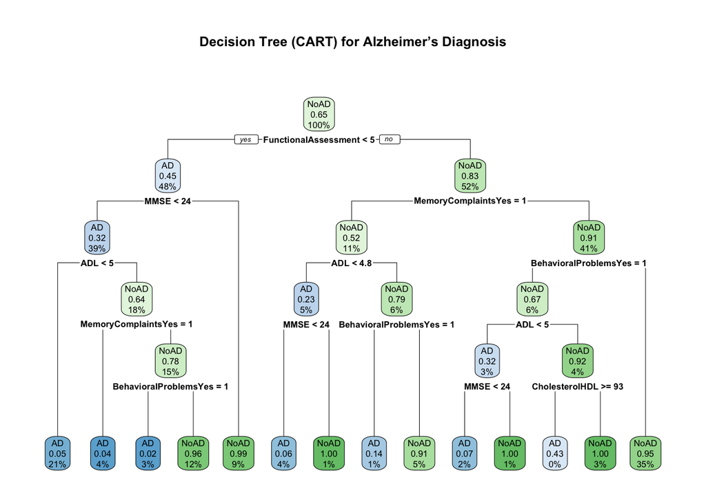

```r
# Plot the decision tree
rpart.plot(model_tree$finalModel, type = 2, extra = 106, fallen.leaves = TRUE,
           main = "Decision Tree (CART) for Alzheimer’s Diagnosis")
```

#### Visione Complessiva

**Predittori principali:**

- **FunctionalAssessment** (split principale)
- **ADL** (abilità nelle attività quotidiane)
- **MMSE** (test cognitivo)
- **MemoryComplaints**, **BehavioralProblems**

Questi risultati riflettono il ragionamento clinico: il declino funzionale e il deterioramento cognitivo oggettivo sono i principali indicatori di **AD**, mentre i sintomi auto‑riportati e i comportamenti aggiungono dettagli significativi nella previsione nei casi borderline.

Questo dimostra la capacità del modello di creare sottogruppi altamente omogenei quando diversi indicatori coincidono.

### Modello Random Forest

Per il modello **Random Forest**, utilizziamo il pacchetto **randomForest** tramite *caret* (metodo = “rf”). I principali iperparametri per **Random Forest** includono: - **mtry**: numero di variabili selezionate casualmente per ogni split - **ntree**: numero di alberi - **dimensione del nodo** o **profondità massima** (opzionali)

Per impostazione predefinita, **Random Forest** utilizza **500 alberi** e **$\sqrt{p}$** caratteristiche per **mtry** (dove **$p$** è il numero di predittori).

```r
# Random Forest

# Train a Random Forest with 5-fold CV for evaluating performance
set.seed(123)
model_rf <- train(Diagnosis ~ ., data = train, method = "rf",
                  trControl = ctrl, metric = "ROC",  # optimize by AUC
                  tuneLength = 5)   # try a range of mtry values


# Inspect the final random forest model
model_rf$finalModel  # randomForest object summary
```

```
##
## Call:
##  randomForest(x = x, y = y, mtry = param$mtry)
##                Type of random forest: classification
##                      Number of trees: 500
## No. of variables tried at each split: 10
##
##         OOB estimate of  error rate: 5.25%
## Confusion matrix:
##       AD NoAD class.error
## AD   476   56  0.10526316
## NoAD  23  950  0.02363823
```

Il modello finale **rfModel$finalModel** è un oggetto **randomForest** che contiene l’insieme degli alberi. Possiamo esaminare la stima dell’errore **OOB** (out-of-bag) e l’importanza delle variabili.

### Sintesi e Analisi dei Risultati

Questi risultati suggeriscono che **Random Forest** è un modello efficace per la classificazione dell’Alzheimer, riuscendo a identificare correttamente la maggior parte dei pazienti AD e NoAD. Tuttavia, vi è ancora un margine di miglioramento, in particolare per ridurre il numero di falsi negativi per i casi di **AD**. La performance complessiva del modello è solida e potrebbe essere ulteriormente migliorata attraverso l’ottimizzazione degli iperparametri o l’uso di modelli aggiuntivi per trattare i falsi negativi.

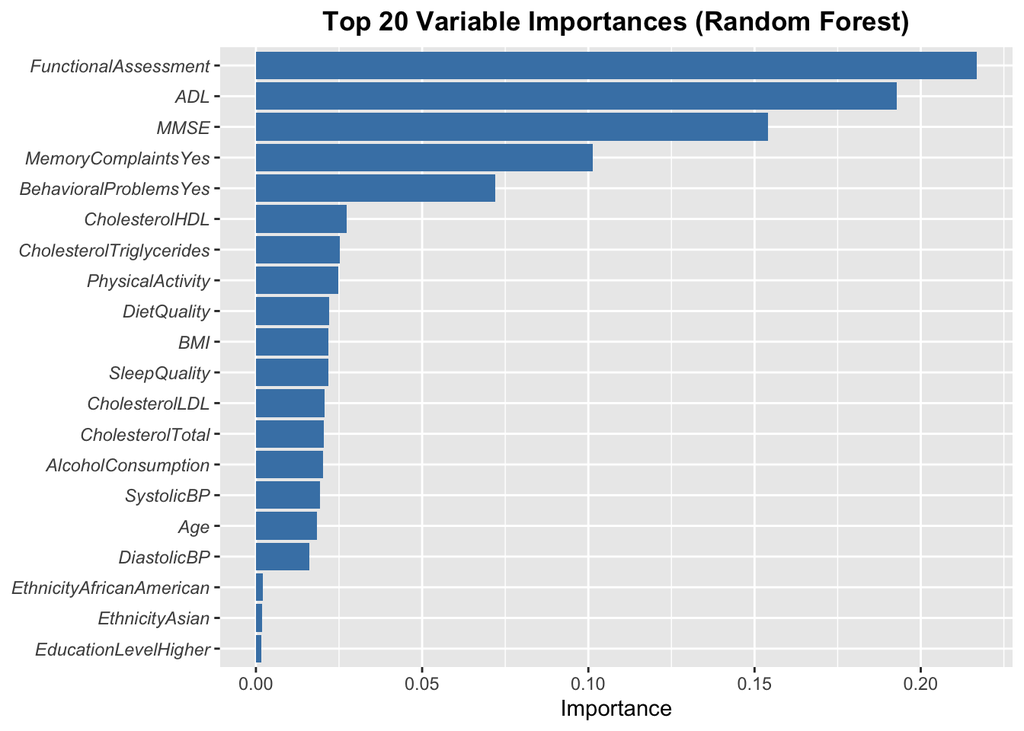

```r
# Extract the variable importance data.frame
imp_df <- varImp(model_rf)$importance
imp_df$Variable <- rownames(imp_df)

# Keeping only want the top 20 (as printed), you can slice:
imp_df <- imp_df[order(imp_df$Overall, decreasing = TRUE), ][1:20, ]

# Plot as a horizontal bar chart
ggplot(imp_df, aes(x = reorder(Variable, Overall), y = Overall/sum(Overall))) +
  geom_col(fill = "steelblue") +
  coord_flip() +
  labs(
    title = "Top 20 Variable Importances (Random Forest)",
    x     = NULL,
    y     = "Importance"
  ) +
  theme(
    plot.title = element_text(face = "bold", hjust = 0.5),
    axis.text.y = element_text(face = "italic")
  )
```

L’output fornirà un punteggio di importanza per ciascuna variabile (Media della Riduzione dell’Impurità di Gini). Ci aspettiamo un pattern simile: le misure cognitive e funzionali probabilmente saranno al top, seguite eventualmente da alcuni fattori legati alla salute. I random forest possono talvolta scoprire interazioni che un singolo albero non ha rilevato, quindi potremmo osservare l’importanza crescente di variabili aggiuntive.

### Modello XGBoost

Per **XGBoost**, utilizziamo il pacchetto **xgboost**. *caret* fornisce un metodo “xgbTree” che si interfaccia con **xgboost** e consente di ottimizzare diversi iperparametri: ad esempio, **nrounds** (numero di round di boosting/alberi), **max_depth** degli alberi, **eta** (tasso di apprendimento), **gamma** (riduzione minima della perdita per il split), **colsample_bytree** (frazione di caratteristiche da utilizzare per ogni albero), **min_child_weight** (somma minima del peso delle istanze (Hessiano) in un nodo figlio) e **subsample** (frazione di osservazioni da sottocampionare per ogni albero).  
L’ottimizzazione di tutti questi parametri può essere costosa dal punto di vista computazionale, quindi spesso si fissano alcuni parametri e si ottimizzano gli altri.

```r
# XGBoost

# XGBoost model training and tuning
set.seed(123)
model_xgb <- train(Diagnosis ~ ., data = train, method = "xgbTree",
                   trControl = ctrl, metric = "ROC",
                   tuneLength = 5, verbosity=0)  # tune depth, nrounds, etc., with 5 possible combos


# Extract the underlying xgboost model (for direct use with SHAP, etc.)
xgb_booster <- model_xgb$finalModel
xgb_booster
```

```
## ##### xgb.Booster
## raw: 170.6 Kb
## call:
##   xgboost::xgb.train(params = list(eta = param$eta, max_depth = param$max_depth,
##     gamma = param$gamma, colsample_bytree = param$colsample_bytree,
##     min_child_weight = param$min_child_weight, subsample = param$subsample),
##     data = x, nrounds = param$nrounds, objective = "binary:logistic",
##     verbosity = 0)
## params (as set within xgb.train):
##   eta = "0.3", max_depth = "5", gamma = "0", colsample_bytree = "0.8", min_child_weight = "1", subsample = "1", objective = "binary:logistic", verbosity = "0", validate_parameters = "TRUE"
## xgb.attributes:
##   niter
## callbacks:
##   cb.print.evaluation(period = print_every_n)
## # of features: 36
## niter: 100
## nfeatures : 36
## xNames : Age GenderFemale EthnicityAfricanAmerican EthnicityAsian EthnicityOther EducationLevelHighSchool EducationLevelUndergrad EducationLevelHigher BMI SmokingYes AlcoholConsumption PhysicalActivity DietQuality SleepQuality FamilyHistoryAlzheimersYes CardiovascularDiseaseYes DiabetesYes Depres…
## problemType : Classification
## tuneValue :
##      nrounds max_depth eta gamma colsample_bytree min_child_weight subsample
## 247     100         5 0.3     0              0.8                1         1
## obsLevels : AD NoAD
## param :
##  $verbosity
## [1] 0
```

Possiamo esaminare anche l’importanza delle variabili nel modello **XGBoost**. XGBoost fornisce l’importanza delle caratteristiche tramite tre metriche: **weight** (numero di volte che una variabile è stata utilizzata per gli split), **gain** (miglioramento nella perdita attribuito alla variabile), o **cover** (percentuale di campioni coperti dalla variabile). Il metodo **varImp** di caret per **xgbTree** utilizza tipicamente la metrica **gain** di default:

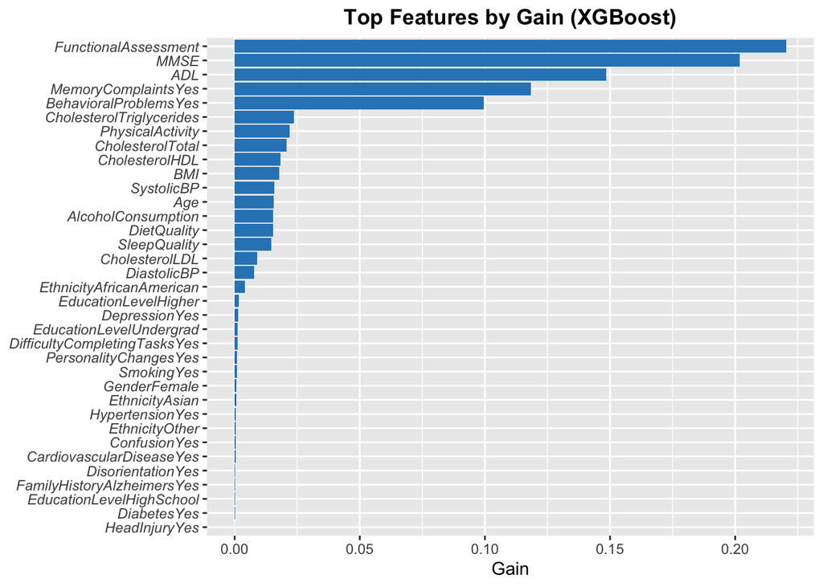

```r
# Get importance table
imp.xgb <- xgb.importance(model = xgb_booster)

# Take top features in order
imp.xgb20 <- imp.xgb[order(imp.xgb$Gain, decreasing = TRUE)]

# Horizontal bar chart
ggplot(imp.xgb20, aes(x = reorder(Feature, Gain), y = Gain)) +
  geom_col(fill = "#2E86C1") +
  coord_flip() +
  labs(
    title = "Top Features by Gain (XGBoost)",
    x     = NULL,
    y     = "Gain"
  ) +
  theme(
    plot.title = element_text(face = "bold", hjust = 0.5),
    axis.text.y = element_text(face = "italic")
  )
```

### Interpretazione del grafico di Gain per XGBoost

In sintesi, XGBoost apprende sostanzialmente la stessa gerarchia del Random Forest, ma la quantifica tramite il “gain di informazione” del boosting ad albero. Il forte declino del Gain oltre le prime cinque variabili suggerisce che un modello più semplice, basato solo su questi predittori principali, potrebbe ottenere prestazioni quasi equivalenti con tempi di addestramento più rapidi e maggiore **interpretabilità**.

### Modello LightGBM

Integrare **LightGBM** in *caret* non è immediato, poiché *caret* non dispone di un metodo “lightgbm” tra quelli inclusi di default. Possiamo comunque addestrare un modello LightGBM utilizzando direttamente il pacchetto **lightgbm**. Useremo una semplice procedura di tuning tramite la cross‑validation interna di LightGBM o con un ciclo manuale, per poi confrontare i risultati con gli altri modelli. Per garantire la correttezza del confronto utilizzeremo gli stessi dati di training e una **cross‑validation a 5 fold**.

Prima di tutto è necessario preparare i dati nel formato richiesto da LightGBM:  
- le feature devono essere fornite come **matrice**;  
- l’etichetta dev’essere un vettore numerico 0/1 (o un fattore che LightGBM convertirà internamente).

Con il training set creeremo quindi un oggetto **`lgb.Dataset`** e useremo **`lgb_cv`** per la cross‑validation, al fine di ottimizzare il numero di round (cioè il numero di alberi) prima di addestrare il modello finale.

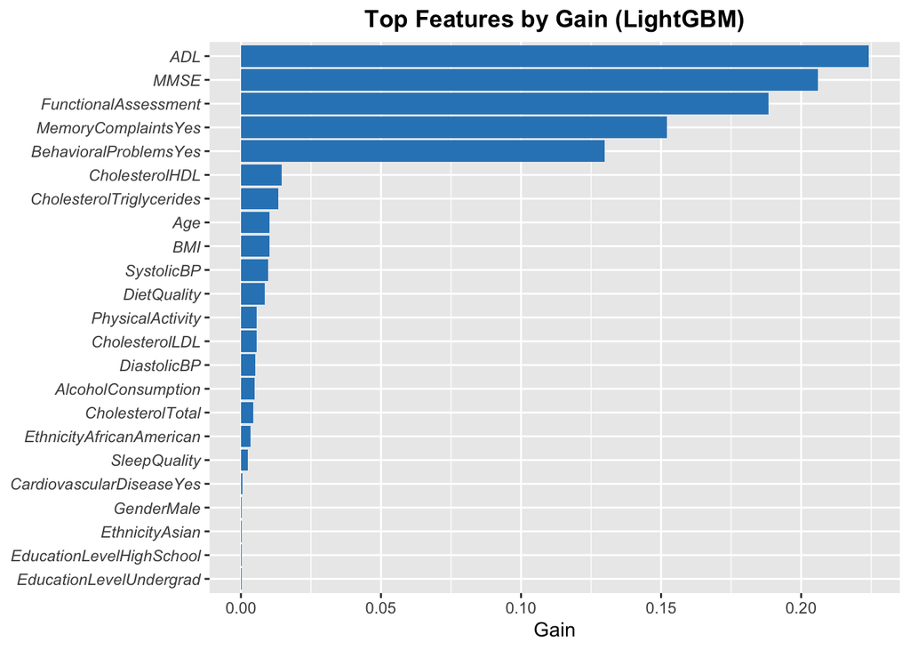

```r
# LightGBM

# Prepare data for LightGBM: LightGBM expects numeric matrix input
# We'll one-hot encode factors for LightGBM
train_mat <- model.matrix(Diagnosis ~ . - 1, data = train)  # one-hot encoding (no intercept)
train_label <- ifelse(train$Diagnosis == "AD", 1, 0)        # label as 0/1
test_mat  <- model.matrix(Diagnosis ~ . - 1, data = test)
test_label <- ifelse(test$Diagnosis == "AD", 1, 0)

# Create lgb.Dataset objects
dtrain <- lgb.Dataset(data = train_mat, label = train_label)

# Set LightGBM parameters for binary classification
params <- list(objective = "binary", metric = "auc", verbose = -1)

# Perform cross-validation to find optimal number of trees (nrounds) with early stopping
set.seed(123)
lgb_cv <- lgb.cv(params = params, data = dtrain, nfold = 5, nrounds = 1000,
                 early_stopping_rounds = 10, verbose = 0)

best_iter <- lgb_cv$best_iter  # optimal number of boosting rounds from CV

# Train final LightGBM model with best number of rounds
model_lgb <- lgb.train(params = params, data = dtrain, nrounds = best_iter)

# Get importance table
imp.lgb <- lgb.importance(model = model_lgb)

# Take top features in order
imp.lgb20 <- imp.lgb[order(imp.lgb$Gain, decreasing = TRUE)]

# Horizontal bar chart
ggplot(imp.lgb20, aes(x = reorder(Feature, Gain), y = Gain)) +
  geom_col(fill = "#2E86C1") +
  coord_flip() +
  labs(
    title = "Top Features by Gain (LightGBM)",
    x     = NULL,
    y     = "Gain"
  )+
  theme(
    plot.title = element_text(face = "bold", hjust = 0.5),
    axis.text.y = element_text(face = "italic")
  )
```

```r
# Predict on test set with each model
pred_tree <- predict(model_tree, newdata = test)         # predicted classes
pred_rf   <- predict(model_rf, newdata = test)
pred_xgb  <- predict(model_xgb, newdata = test)

# For LightGBM, use the model to predict probabilities and then class
prob_lgb  <- predict(model_lgb, test_mat)                # probability of class 1 (AD)
pred_lgb  <- factor(ifelse(prob_lgb > 0.5, "AD", "NoAD"), levels = c("AD","NoAD"))

# Confusion matrices for each model
cm_tree <- confusionMatrix(pred_tree, test$Diagnosis, positive = "AD")
cm_rf   <- confusionMatrix(pred_rf,   test$Diagnosis, positive = "AD")
cm_xgb  <- confusionMatrix(pred_xgb,  test$Diagnosis, positive = "AD")
cm_lgb  <- confusionMatrix(pred_lgb,  test$Diagnosis, positive = "AD")

# Print Accuracy, Sensitivity, Specificity for each model
metrics <- rbind(
  c(cm_tree$overall["Accuracy"], cm_tree$byClass[c("Sensitivity","Specificity")]),
  c(cm_rf$overall["Accuracy"],   cm_rf$byClass[c("Sensitivity","Specificity")]),
  c(cm_xgb$overall["Accuracy"],  cm_xgb$byClass[c("Sensitivity","Specificity")]),
  c(cm_lgb$overall["Accuracy"],  cm_lgb$byClass[c("Sensitivity","Specificity")])
)
rownames(metrics) <- c("Decision Tree","Random Forest","XGBoost","LightGBM")
colnames(metrics) <- c("Accuracy","Sensitivity","Specificity")
metrics_df <- as.data.frame(round(metrics, 4))
print(metrics_df)
```

```
##               Accuracy Sensitivity Specificity
## Decision Tree   0.9488      0.9211      0.9639
## Random Forest   0.9519      0.9167      0.9712
## XGBoost         0.9519      0.9123      0.9736
## LightGBM        0.9550      0.9254      0.9712
```

### Interpretazione delle prestazioni dei modelli

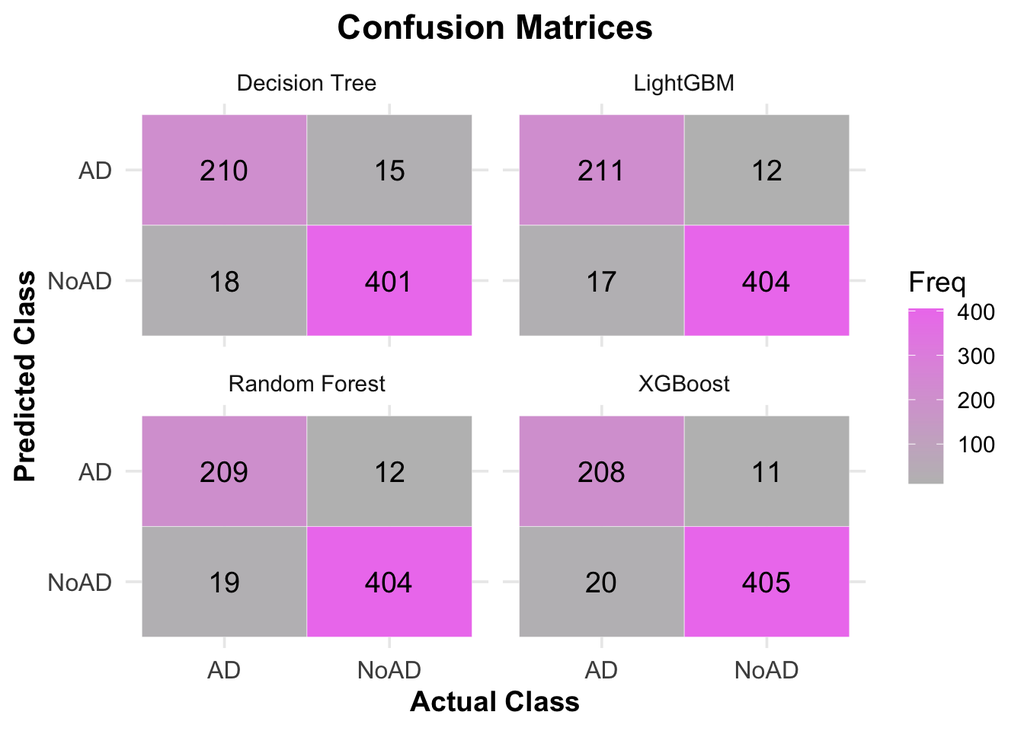

```r
# Combine confusion matrix data for heatmap visualization
cm_list <- list(
  "Decision Tree" = as.data.frame(cm_tree$table),
  "Random Forest" = as.data.frame(cm_rf$table),
  "XGBoost"       = as.data.frame(cm_xgb$table),
  "LightGBM"      = as.data.frame(cm_lgb$table)
)

for(m in names(cm_list)) {
  cm_list[[m]]$Model <- m
  colnames(cm_list[[m]])[1:2] <- c("Prediction","Actual")
}
cm_all <- do.call(rbind, cm_list)


# Plot confusion matrix heatmaps for each model
ggplot(cm_all, aes(x = Actual, y = Prediction, fill = Freq)) +
  geom_tile(color = "white") +
  geom_text(aes(label = Freq), size = 5) +
  scale_fill_gradient(low = "grey", high = "violet") +
  facet_wrap(~ Model, ncol = 2) +
  scale_x_discrete(limits = c("AD","NoAD")) +          # Predicted: AD then NoAD
  scale_y_discrete(limits = c("NoAD","AD")) +
  labs(title = "Confusion Matrices", x = "Actual Class", y = "Predicted Class") +
  theme_minimal(base_size = 14) +
  theme(
    plot.title    = element_text(face = "bold", hjust = 0.5),
    axis.title    = element_text(face = "bold"),
    axis.text     = element_text(size = 12)
  )
```

```r
# Calculate Accuracy and AUC for each model on test set

# Probabilities for ROC (for tree and rf from caret models, we get probabilities)
prob_tree <- predict(model_tree, newdata = test, type = "prob")[, "AD"]
prob_rf   <- predict(model_rf,   newdata = test, type = "prob")[, "AD"]
prob_xgb  <- predict(model_xgb,  newdata = test, type = "prob")[, "AD"]
prob_lgb  <- prob_lgb  # already computed above

# 4.2 ROC Curves and AUC
# --------------------------------------------------------------------
roc_tree <- roc(test$Diagnosis, prob_tree, levels = c("NoAD","AD"), direction="<")
roc_rf   <- roc(test$Diagnosis, prob_rf,   levels = c("NoAD","AD"), direction="<")
roc_xgb  <- roc(test$Diagnosis, prob_xgb,  levels = c("NoAD","AD"), direction="<")
roc_lgb  <- roc(test$Diagnosis, prob_lgb,  levels = c("NoAD","AD"), direction="<")

auc_vals <- c(DecisionTree = auc(roc_tree), RandomForest = auc(roc_rf),
              XGBoost = auc(roc_xgb), LightGBM = auc(roc_lgb))
cat("AUC:\n"); print(round(auc_vals, 4))
```

```
## AUC:
```

```
## DecisionTree RandomForest      XGBoost     LightGBM
##       0.9415       0.9577       0.9577       0.9529
```

### Interpretazione dei risultati AUC

[figure not shown]

```r
# Plot all ROC curves on one graph
roc_list <- list("Decision Tree" = roc_tree, "Random Forest" = roc_rf,
                 "XGBoost" = roc_xgb, "LightGBM" = roc_lgb)
ggroc(roc_list, aes = "colour", size = 1.2) +
  geom_abline(slope = 1, intercept = 0, linetype = "dashed", color = "grey") +
  labs(title = "ROC Curves", x = "False Positive Rate", y = "True Positive Rate", color = "Model") +
  theme_minimal()
```

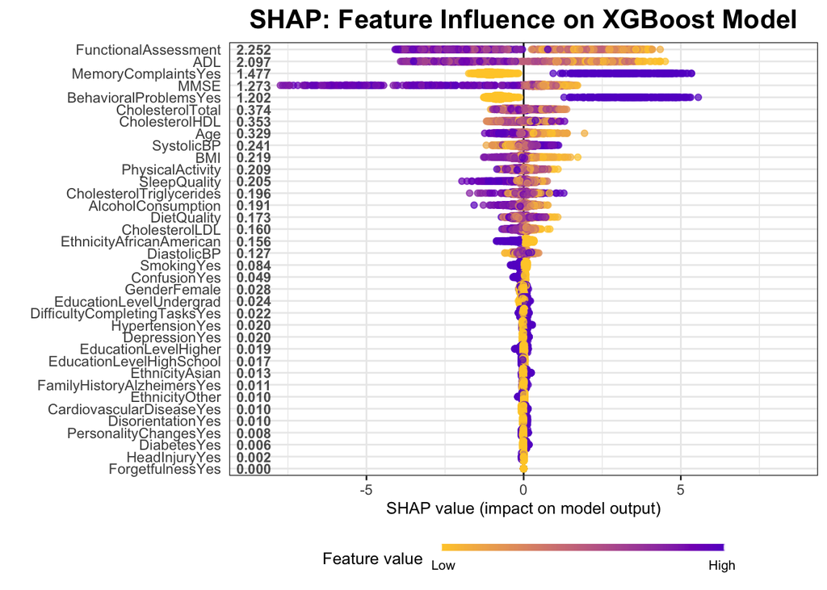

```r
## SHAP: Global Feature Importance

# Compute SHAP values for the XGBoost model on the training data
X_train_mat <- model.matrix(Diagnosis ~ . - 1, data = train)  # matrix of features
booster_feat_names<-xgb_booster$feature_names
X_train_mat <- X_train_mat[, booster_feat_names, drop = FALSE]

shap_values <- shap.values(xgb_model = xgb_booster, X_train = X_train_mat)


# Global feature importance (mean |SHAP value|)
shap_importance <- shap_values$mean_shap_score
shap_importance <- sort(shap_importance, decreasing = TRUE)


# Prepare long-format data for SHAP plots
shap_long <- shap.prep(xgb_model = xgb_booster, X_train = X_train_mat)

# SHAP summary plot (beeswarm plot)

# 1. Generate the SHAP summary plot
shap.plot.summary(shap_long)+
  ggtitle("SHAP: Feature Influence on XGBoost Model") +
  theme(
    plot.title = element_text(hjust = 0.5, size = 16, face = "bold")
  )
```

### Interpretazione del grafico SHAP per il modello XGBoost

#### Caratteristiche principali

- **FunctionalAssessment** è la variabile con i valori SHAP più elevati, quindi ha l’influenza maggiore sulle previsioni del modello.
  - Valori alti di *FunctionalAssessment* spingono fortemente la previsione verso **NoAD**.
  - Valori bassi, al contrario, spingono la previsione verso **AD**.
- **ADL** e **MMSE** esercitano anch’essi un’influenza significativa.
  - *ADL* è particolarmente predittiva quando il punteggio è basso, suggerendo una maggiore probabilità di **AD** negli individui con ridotta autonomia funzionale.
- **MemoryComplaintsYes** e **BehavioralProblemsYes** contribuiscono a raffinare ulteriormente le previsioni.
  - Valori alti di queste variabili aumentano la probabilità di **AD**.

#### Impatti negativi e positivi

- I valori **SHAP** indicano come il valore di ciascuna variabile influenzi l’output finale del modello.
  - Valori alti di *FunctionalAssessment* e *ADL* tendono a spingere la previsione verso **NoAD**; valori bassi verso **AD**.
- Il segno del valore SHAP mostra se la variabile spinge la previsione in senso positivo o negativo (rispettivamente a destra o a sinistra nel grafico).
  - Il gradiente di colore rappresenta il valore della variabile (da basso ad alto), evidenziando come la variazione dei valori influenzi la previsione.

#### Interazione tra variabili

- Il grafico evidenzia interazioni tra le variabili: alcune, come *FunctionalAssessment* e *ADL*, mostrano una dispersione di valori SHAP relativamente ampia.
- Ciò indica che il modello sta apprendendo relazioni non lineari tra le variabili per distinguere **AD** da **NoAD**.

## Conclusioni

In questo progetto abbiamo confrontato quattro modelli basati su alberi decisionali per la classificazione dei casi di Alzheimer (AD) e No-Alzheimer (NoAD): l’albero decisionale (Decision Tree), il Random Forest, l’XGBoost e il LightGBM.

Per quanto riguarda l’importanza delle variabili, tutte le tecniche hanno evidenziato che le variabili relative alle misure cognitive e funzionali (come **MMSE**, **ADL** e **FunctionalAssessment**) sono i fattori più determinanti per la previsione della malattia di Alzheimer. Le variabili relative ai sintomi soggettivi, come **MemoryComplaintsYes** e **BehavioralProblemsYes**, si sono rivelate anche esse molto influenti.

Infine, l’uso di **SHAP** ha permesso di interpretare in modo trasparente i modelli, mostrando chiaramente l’influenza di ciascuna variabile sulle previsioni del modello, un aspetto fondamentale per la validazione clinica dei modelli predittivi.

In sintesi, i modelli di ensemble come **Random Forest** e **XGBoost** sono i più indicati per applicazioni cliniche legate alla diagnosi dell’Alzheimer, grazie alla loro robustezza e capacità di generalizzare meglio rispetto ad un albero decisionale semplice. Tuttavia, è sempre importante considerare le caratteristiche del dataset e l’ambito di applicazione per scegliere il modello più adatto.